# Transcriptomics Normalization and Exploration

- Show All Code
- Hide All Code
- View Source

Published

8 Oct 2026

## Overview:

#### Quality Control and Normalization

0. Sample Information
1. Metadata and group assignment
2. Normalize counts with TMM
3. Gene-filtering
4. Compare re-sequenced samples
5. Differential Gene Expression analysis
6. Exploratory Heatmap
7. UMAP on signifcant genes

### Load Libraries

```r
##################
# LOAD LIBRARIES #
##################
library(tidyverse)
# BiocManager::install("limma")
# BiocManager::install("edgeR")
# BiocManager::install("ComplexHeatmap")
library(limma)
library(edgeR)

library(scales)
library(ComplexHeatmap)
library(circlize)
library(mixOmics)
library(readxl)
library(cowplot)
library(RColorBrewer)
library(ggrepel)

# BiocManager::install("DESeq2")
library(DESeq2)
library(matrixStats)
select <- dplyr::select
map <- purrr::map
rename <- dplyr::rename

# setwd("/Users/vilkal/work/Brolidens_work/Projects/Candida-omics/src")
```

```r
pal <- list(
  CST = c(
    "I" = "#148F77",
    "II" = "#6d9f06",
    "III" = "#A3E4D7",
    "IV-B" = "#E794C1",
    "IV-C" = "#b5cb8c",
    "V" = "#43BA8F"
  ),
  subCST = c(
    "#a5c97b",
    "#cc93cf",
    "#de9548",
    "#63d3b4",
    "#9e8dec",
    "#902267",
    '#FB5273',
    "#91c5de"
  ),
  "Fungal culture: C. albicans (y/n)" = c("#EAEAEA", "#fd814e"),
  RVVC = c("#EAEAEA", "#fd814e"),
  BV = c("#EAEAEA", "#fd814e"),
  NAC = c("#EAEAEA", "#fd814e"),
  ST = c("#EAEAEA", "#fd814e"),
  missing_page = c("#EAEAEA", "#fd814e"),
  Clin = c("#a5c97b", "#cc93cf", "#de9548", "#63d3b4", "#9e8dec", "#902267"),
  Clin_gr = c("#ffa998", '#FB5273', "#902267"),
  RVVC_AS = c("#ffa998", '#FB5273', "#902267"),
  RVVC_pos = c(
    "#A6CEE3",
    "#1F78B4",
    #"#EAEAEA",
    #"gray",
    "#e490c4ff",
    "#c12d88ff"
  ), # "#FB9A99", "#E31A1C", "#B2DF8A", "#609c5bff", "#FDBF6F", "#FF7F00",, "#CAB2D6", "#6a3d9a" "#e490c4ff", "#c12d88ff"
  trx_louvain_7 = c(
    "#de9548",
    "#cc93cf",
    "#a5c97b",
    "#9e8dec",
    "#902267",
    "#63d3b4"
    #'#FB5273'
  ),
  metab_louvain = c(
    "#cc93cf",
    "#a5c97b",
    "#de9548",
    "#902267",
    "#9e8dec",
    "#63d3b4"
    #'#FB5273'
  ),
  microb_louvain = c(
    "#cc93cf",
    "#de9548",
    "#a5c97b",
    "#9e8dec",
    "#902267",
    "#63d3b4",
    '#FB5273',
    "#B3CDE3"
  ),
  fun_louvain = c(
    "#a5c97b",
    "#cc93cf",
    "#de9548",
    "#63d3b4",
    "#9e8dec",
    "#902267",
    '#FB5273'
    #"#984EA3"
    #"#B3CDE3"
  ),
  integ_louvain = c(
    "#a5c97b",
    "#cc93cf",
    "#de9548",
    "#63d3b4",
    "#9e8dec",
    "#902267",
    '#FB5273',
    "#984EA3"
    #"#B3CDE3"
  ),
  "Wet_smear:_clue_cells_(y/n)" = c("#2266ac", "#91c5de"),
  hyphae = c("#f26386", "#fd814e", "#a4d984", "#fbbc52"),
  pos = c("#91c5de", "#2266ac"),
  fct1_clus = c("#33A02C", "#B2DF8A", "#FF7F00", "#FDBF6F"), #"#FDBF6F" "#FF7F00", "#CAB2D6", "#6A3D9A"
  "Clinical score (0-5)" = brewer.pal(6, name = "Reds"),
  "Clinical_score_(0-5)" = brewer.pal(6, name = "Reds")
)

gg_color_hue <- function(n) {
  hues <- seq(15, 375, length = n + 1)
  hcl(h = hues, l = 65, c = 100)[1:n]
}

# colour pallets
blue <- brewer.pal(6, name = "Blues") %>% c(., "gray")
Red <- brewer.pal(6, name = "Reds") #%>% c(., "gray")
pal4 <- c("#f26386", "#fd814e", "#a4d984", "#fbbc52") # "#f588af", "#fd814e"
pal2 <- c("#2266ac", "#91c5de")

#Red <- brewer.pal(6, name = "Reds") #%>% c(., "gray")
pal1 <- c("#ffa998", "#f17730ff", "#902267") #
pal3 <- c("#9e8dec", "#cc93cf", "#a5c97b", "#de9548") #"#abcb4b" "#63d3b4" "#902267",
```

## Sample Information

There are only two biopsies collected in the longitudinal study —  
at **visit 02** and **visit 04**, corresponding to **baseline** and the **3-month follow-up**.

#### Visits:

- **01** – Inclusion
- **02** – Secretion + biopsy (**baseline**)
- **03** – Secretion only (**1 week post-treatment**)
- **04** – Secretion + biopsy (**3 months post-treatment**)
- **05** – Secretion only (**6 months post-treatment**)

#### Sequencing Runs

The samples have been run in three sequencing batches:

- **Run 1:** `BEA23P074` (n = 38)
- **Run 2:** `BEA24P003` (n = 54)
- **Run 3:** `BEA26P064` (n = 24)

#### Sample Summary

Based on the files delivered from BEA, I believe we have sequenced:  
**97 unique samples**, of which **79 are baseline** and **18 are 3-month follow-up**.

NB! The baseline sample of **(S69)** has `12:01` (DS_ID) listed as baseline instead of `12:02`. This was a mistake, but we decided to keep it.

#### Potential Control Samples

There are six samples that might be **controls**, but this is uncertain.  
I could not find any documentation explaining their naming:

FF060322243, FF060322244, 231025:1, 230918., 231108:1, 231108:1

```r
#############
# LOAD DATA #
#############
Clin_path <- "../data/Metadata_svamp_FINAL.xlsx"
comb_meta_path <- "../Results/Combined_gr_meta_data_all.csv"
m <- read_csv("../Results/Sample_omic_table.csv")

# meta data
Clin_data <- read_xlsx(Clin_path, sheet = "Metadata", na = "na")
meta <- read_csv(comb_meta_path) %>%
  #rename(svamp_ID = "sample") %>%
  mutate(across(2:27, ~ factor(.x)))

trx_path <- "../Tidy_data/Transcriptomics/Counts_all_trx_samples.csv"
raw_matrix <- read_csv(trx_path)

mapping_path <- "../Tidy_data/Transcriptomics/Mapping_all_trx_samples.csv"
trx_mapping <- read_csv(mapping_path)
```

```r
meta_trx <- meta %>%
  filter(svamp_ID %in% colnames(raw_matrix))

meta_ <- meta %>%
  filter(!(grepl("_1W|_6M", .$svamp_ID)))

table(meta_trx$RVVC_pos)
missing_trx <- setdiff(meta_$svamp_ID, meta_trx$svamp_ID)

in_freezer <- c(
  "S91_3M",
  "S89_3M",
  "S91_BL",
  "S87_3M",
  "S90_3M",
  "S77_3M",
  "S76_3M",
  "S79_3M",
  "S82_3M",
  "S83_3M",
  "S87_BL",
  "S88_BL",
  "S90_BL",
  "S89_BL",
  "S85_3M",
  "S86_BL"
)
low_RIN <- c(
  "S14",
  "S16",
  "S11",
  "S18",
  "S64_BL",
  "S1",
  "S8",
  "S76_BL",
  "S33",
  "S79_BL"
)
no_biopsy <- c(
  "S31",
  "S32",
  "S65_BL",
  "S65_3M",
  "S21",
  "S24",
  "S28",
  "S78_3M",
  "S84_BL"
)

m <- meta %>%
  filter(svamp_ID %in% missing_trx) %>%
  select(svamp_ID, RVVC_pos, BV, NAC, CST) %>%
  mutate(reason = ifelse(svamp_ID %in% in_freezer, "in_freezer", NA)) %>%
  mutate(reason = ifelse(svamp_ID %in% low_RIN, "low_RIN", .$reason)) %>%
  mutate(reason = ifelse(svamp_ID %in% no_biopsy, "no_biopsy", .$reason)) %>%
  arrange(reason, RVVC_pos)

write_csv(
  m,
  "/Users/vilkal/work/Brolidens_work/Projects/Candida-omics/Tidy_data/Transcriptomics/Transcriptome_missing_samples.csv"
)
```

```r
trx_mapping %>%
  mutate(
    sample_type = case_when(
    str_detect(svamp_ID, "NA_") ~ "QC",
    str_detect(svamp_ID, regex("run", ignore_case = TRUE)) ~ "batch",
    str_detect(svamp_ID, "_(3M|1W|6M)$") ~ "followup",
    str_detect(svamp_ID, "^S\\d\\d$|^S\\d\\d_BL") ~ "baseline",
    TRUE ~ NA_character_
    ), .after="svamp_ID"
) %>% split(~Batch) %>% map(., ~summarise(.x, n_samples = n(), .by="sample_type"))
```

```
$BEA23P074
# A tibble: 3 × 2
  sample_type n_samples
  <chr>           <int>
1 baseline           29
2 batch               5
3 followup            4

$BEA24P003
# A tibble: 3 × 2
  sample_type n_samples
  <chr>           <int>
1 QC                  6
2 baseline           44
3 followup            4

$BEA26P064
# A tibble: 3 × 2
  sample_type n_samples
  <chr>           <int>
1 batch               8
2 followup           10
3 baseline            6
```

### Some quick QC

```
Ignoring unknown labels:
• shape : "RIN available"
```

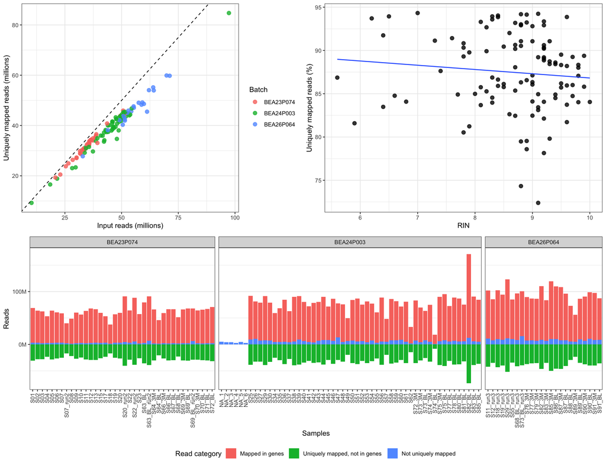

```r
trx_qc <- trx_mapping %>%
  mutate(
    Batch = str_extract(trx_mapping$`BEA ID`, "^[^_]+"),
    input_reads = as.numeric(Number_of_input_reads),
    uniquely_mapped = as.numeric(Number_uniquely_mapped),
    mapping_rate = uniquely_mapped / input_reads * 100
  )

# Sequencing depth vs uniquely mapped reads
p_depth <- ggplot(
  trx_qc,
  aes(x = input_reads / 1e6, y = uniquely_mapped / 1e6)
) +
  geom_point(aes(col = Batch), size = 2.5, alpha = 0.8) +
  geom_abline(slope = 1, intercept = 0, linetype = 2) +
  labs(
    x = "Input reads (millions)",
    y = "Uniquely mapped reads (millions)",
    shape = "RIN available"
  ) +
  theme_bw()

# RIN vs mapping rate:
p_rin <- trx_qc %>%
  filter(!is.na(RIN)) %>%
  ggplot(aes(x = RIN, y = mapping_rate)) +
  geom_point(size = 2.5, alpha = 0.8) +
  geom_smooth(method = "lm", se = FALSE, linewidth = 0.7) +
  labs(
    x = "RIN",
    y = "Uniquely mapped reads (%)"
  ) +
  theme_bw()

# reads per batch overview:
sum_reads <- as.numeric(summarise(
  raw_matrix,
  across(matches("S\\d\\d"), ~ sum(.x, na.rm = TRUE))
)[1, ])
names(sum_reads) <- colnames(select(raw_matrix, matches("S\\d\\d")))
trx_qc <- trx_mapping %>%
  mutate(
    Batch = str_extract(trx_mapping$`BEA ID`, "^[^_]+"),
    total = as.numeric(Number_of_input_reads),
    unique = as.numeric(Number_uniquely_mapped),
    # calculate the missing values
    genes = sum_reads[svamp_ID] * 2,
    .after = "Number_mapped_in_genes",

    other = total - unique,
    unique_not_genes = unique - genes
  ) %>%
  select(svamp_ID, total, other, unique_not_genes, genes, Batch) %>%
  pivot_longer(
    cols = c(other, unique_not_genes, genes),
    names_to = "read_category",
    values_to = "reads"
  ) %>%
  mutate(
    read_category = factor(
      read_category,
      levels = c("genes", "unique_not_genes", "other"),
      labels = c(
        "Mapped in genes",
        "Uniquely mapped, not in genes",
        "Not uniquely mapped"
      )
    )
  )


batch <- ggplot(
  trx_qc,
  aes(
    x = svamp_ID,
    y = reads,
    fill = read_category
  )
) +
  geom_col(width = 0.9) +
  scale_y_continuous(
    labels = scales::label_number(scale = 1e-6, suffix = "M")
  ) +
  labs(
    x = "Samples",
    y = "Reads",
    fill = "Read category"
  ) +
  theme_bw() +
  theme(
    legend.position = "bottom",
    axis.text.x = element_text(
      angle = 90,
      hjust = 1,
      vjust = 0.5
    ),
    panel.grid.major.x = element_blank()
  ) +
  facet_wrap(~Batch, space = "free_x", scales = "free_x")

# quartz(width = 13, height = 8, dpi = 120)
plot_grid(plot_grid(p_depth, p_rin), batch, ncol = 1)
```

The faceted bar plot illustrates the allocation of sequencing reads across samples and sequencing batches, with the majority of reads being uniquely mapped and subsequently assigned to genes. Each category is mutualy exclusive, with each read beeing represented exactly once:

Total input reads:  
├── Not uniquely mapped  
├── Uniquely mapped, not in genes  
└── Mapped in genes

## Step 1: Metadata and group assignment

NB! the reccuring fungal infection question was only answered once at baseline, thus you ave to extraploate from the baseline if they have it at follow up

### Check the distribution of samples per groups

```r
vars <- c(
  "RVVC_pos",
  "Clinical score (0-5)",
  "Clin_gr",
  "hyphae",
  "group_cross"
) %>%
  set_names()
meta_filt <- meta %>%
  filter(meta$svamp_ID %in% colnames(raw_matrix))
map(vars, ~ table(meta_filt[[.x]]))
```

```
$RVVC_pos

Control_neg Control_pos    RVVC_neg    RVVC_pos
         30          11          23          33

$`Clinical score (0-5)`

 0  1  2  3  4  5
57  8 14  7  7  4

$Clin_gr

  0 1-3 4-5
 57  29  11

$hyphae

  Control Control_H      RVVC    RVVC_H
       38         3        31        25

$group_cross

     AS Control RVVCneg RVVCpos
      7      32       9      27
```

### Get count table

```r
# remove quality controll samples
# assuming that the NA_1-6 samples are quality ctrls,
# we remove them before normalizing and filtering
countTable <- raw_matrix %>%
  select(-starts_with("NA")) # %>%
#select(-ends_with("_run2"))

# Create matrix countTable
countTable <- countTable %>%
  filter(!is.na(symbol)) %>% # remove rows without a symbol
  filter(gene_biotype == "protein_coding") %>%

  filter(rowSums(across(matches("S\\d\\d")) != 0) > 0) #%>% # remove rows that are all zeros

# select(-c(3:9)) %>% # remove metadata columns
# summarise(
#   across(where(is.numeric), \(x) sum(x, na.rm = TRUE)),
#   .by = "symbol"
# )

vars <- c(
  "symbol",
  "gene_biotype",
  "entrez",
  "Chr",
  "Start",
  "End",
  "Strand",
  "Length"
)
ensembl_info <- select(countTable, ensembl, any_of(vars))
ensembl_to_symbol <- set_names(ensembl_info$symbol, ensembl_info$ensembl)
# write.csv("../Tidy_data/Transcriptomics/ensembl_info.csv")

ensembl_info %>%
  select(ensembl, symbol) %>%
  group_by(symbol) %>%
  summarise(
    n_rows = n(),
    ensembl = paste(ensembl, collapse = ", "),
    .groups = "drop"
  ) %>%
  arrange(desc(n_rows)) %>%
  filter(n_rows > 1)
```

```
# A tibble: 4 × 3
  symbol  n_rows ensembl
  <chr>    <int> <chr>
1 CD99         2 ENSG00000002586, ENSG00000292348
2 POLR2J3      2 ENSG00000168255, ENSG00000285437
3 VAMP7        2 ENSG00000124333, ENSG00000292366
4 ZBED1        2 ENSG00000214717, ENSG00000292345
```

```r
# number of uniqe samples excluding "_run2" samples
samples <- select(
  countTable,
  matches("S\\d\\d+") & !(matches("_run2$|_run3$"))
) %>%
  colnames()
length(samples)
```

```
[1] 97
```

```r
MOFA_samples <- intersect(samples, m$sample[m$at_least_two & m$all_BL])
```

## Step 2: Normalize counts with TMM

```r
# get normalized matrix
# Create DGElist object to relate counts to groups
matrix <- select(countTable, -c(3:9), -symbol)
dge <- matrix %>%
  column_to_rownames(., var = "ensembl") %>%
  DGEList(., genes = ensembl_info)

# Normalize counts with TMM
dge_TMM <- calcNormFactors(dge, method = "TMM")
```

```
calcNormFactors has been renamed to normLibSizes
```

## Step 3: Gene-filtering

### Alternative 1:

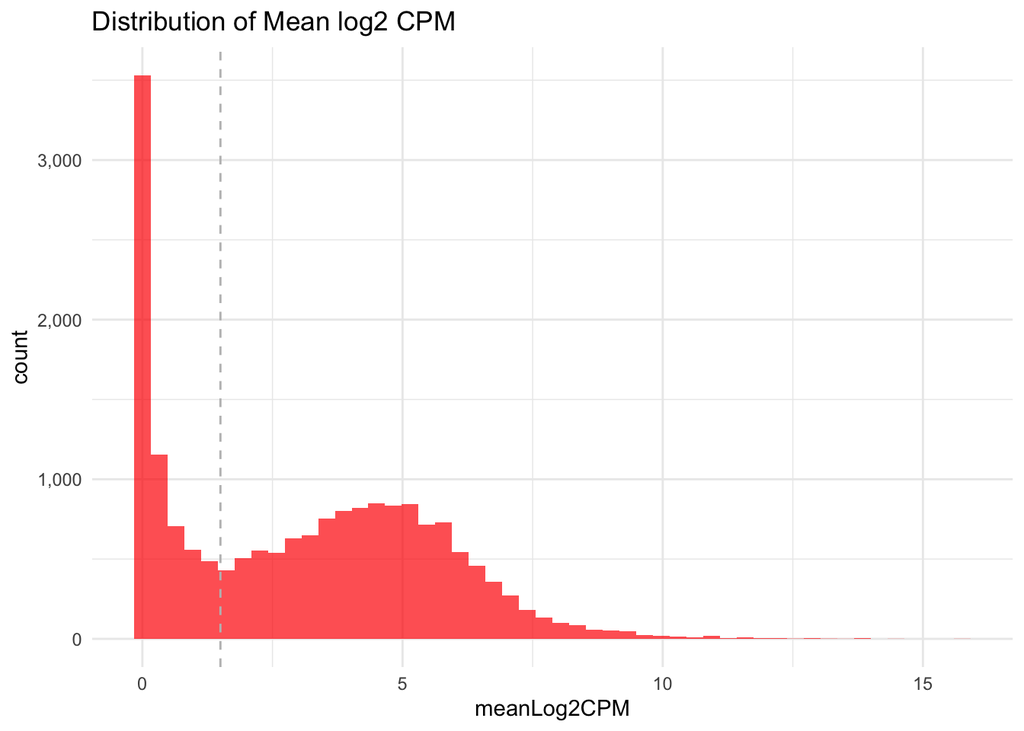

Figure 1: Histogram of mean log2 CPM expression per gene. The vertical gray dashed line marks 1.5 log2 cpm

```r
# Identify low count cut-off
meanLog2CPM <- rowMeans(log2(cpm(matrix[, -1]) + 1))
# hist(meanLog2CPM)
ggplot() +
  geom_histogram(aes(meanLog2CPM), fill = "red", alpha = 0.7, bins = 50) +
  theme_minimal() +
  scale_y_continuous(labels = label_comma()) + # <-- commas
  geom_vline(xintercept = 1.5, color = "gray", linetype = "dashed") +
  ggtitle("Distribution of Mean log2 CPM")
```

```r
# number of genes that will be removed:
s <- sum(meanLog2CPM <= 1.5)

# knitr::kable(., digits = 1)
# Alternative 1.
genes_keep_1 <- countTable %>%
  filter(rowMeans(across(any_of(MOFA_samples))) > 1.5) %>%
  pluck(., "ensembl")

# look at top filtered genes:
countTable %>%
  mutate(
    meanLog2CPM = rowMeans(across(any_of(MOFA_samples))),
    .after = "symbol"
  ) %>%
  mutate(
    cumulative_sum = rowSums(across(any_of(MOFA_samples))),
    .after = "symbol"
  ) %>%
  filter(meanLog2CPM < 1.5) %>%
  arrange(desc(cumulative_sum)) %>%
  select(1:4)
```

```
# A tibble: 2,723 × 4
   ensembl         symbol   cumulative_sum meanLog2CPM
   <chr>           <chr>             <dbl>       <dbl>
 1 ENSG00000286522 H3C2                118        1.49
 2 ENSG00000136197 C7orf25             118        1.49
 3 ENSG00000132554 RGS22               118        1.49
 4 ENSG00000126838 PZP                 118        1.49
 5 ENSG00000231887 PRH1                118        1.49
 6 ENSG00000139973 SYT16               118        1.49
 7 ENSG00000277399 GPR179              118        1.49
 8 ENSG00000180509 KCNE1               118        1.49
 9 ENSG00000146090 RASGEF1C            117        1.48
10 ENSG00000186297 GABRA5              117        1.48
# ℹ 2,713 more rows
```

### Alternative 2:

Another aproach is to filter genes by setting a minimum treshold of reads/counts per million in x number of samples e.g > 1 CPM in three samples > 5 CPM in three samples > 1 read in 5 samples

Keep genes where CPM > 1 in more than 3 samples

```r
# Alternative 2.
# get counts per mullion (CPM) not logged, for filtering:
cpm_TMM <- cpm(dge_TMM, log = FALSE)

genes_keep_2 <- cpm_TMM %>%
  as_tibble(., rownames = "ensembl") %>%
  filter(rowSums(across(all_of(MOFA_samples), ~ .x >= 1)) >= 3) %>%
  pluck(., "ensembl")

# look at top filtered genes:
cpm_TMM %>%
  as_tibble(., rownames = "ensembl") %>%
  filter(!(ensembl %in% genes_keep_2)) %>%
  mutate(
    n_over_1cpm = rowSums(across(all_of(MOFA_samples), ~ .x >= 1)),
    .after = "ensembl"
  ) %>%
  mutate(
    sum_cpm = rowSums(across(all_of(MOFA_samples))),
    .after = "ensembl"
  ) %>%
  mutate(symbol = ensembl_to_symbol[.$ensembl], , .after = "ensembl") %>%
  filter(n_over_1cpm < 3) %>%
  arrange(desc(n_over_1cpm)) %>%
  select(1:4)
```

```
# A tibble: 4,339 × 4
   ensembl         symbol  sum_cpm n_over_1cpm
   <chr>           <chr>     <dbl>       <dbl>
 1 ENSG00000173947 CIMAP3    34.8            2
 2 ENSG00000143167 GPA33     25.0            2
 3 ENSG00000116183 PAPPA2     6.25           2
 4 ENSG00000183780 SLC35F3   22.4            2
 5 ENSG00000213085 CFAP45    25.7            2
 6 ENSG00000175279 CENPS     28.8            2
 7 ENSG00000143570 SLC39A1   40.2            2
 8 ENSG00000189410 SH2D5     20.0            2
 9 ENSG00000162620 LRRIQ3    24.9            2
10 ENSG00000180875 GREM2     18.8            2
# ℹ 4,329 more rows
```

```r
length(genes_keep_1)
```

```
[1] 15789
```

```r
length(genes_keep_2)
```

```
[1] 14173
```

```r
length(intersect(genes_keep_1, genes_keep_2))
```

```
[1] 14173
```

```r
# Check for duplicate symbols:
ensembl_info %>%
  filter(ensembl %in% genes_keep_2) %>%
  group_by(symbol) %>%
  summarise(n = n()) %>%
  arrange(desc(n))
```

```
# A tibble: 14,173 × 2
   symbol      n
   <chr>   <int>
 1 A2M         1
 2 A2ML1       1
 3 A4GALT      1
 4 AAAS        1
 5 AACS        1
 6 AADAC       1
 7 AADACL2     1
 8 AADAT       1
 9 AAGAB       1
10 AAK1        1
# ℹ 14,163 more rows
```

```r
# Step 3. filter low abundant genes
# DEGlist object
dge_TMM_filt <- dge_TMM[genes_keep_2, ]

# count table
countTable_filt <- countTable %>%
  filter(ensembl %in% genes_keep_2)
```

## Step 4: Save filtered and normalized counts

```r
########################
# SAVE NORMALIZED DATA #
########################
cpm_log_TMM <- cpm(dge_TMM_filt, log = T) # for heatmap
rownames(cpm_log_TMM) <- ensembl_to_symbol[rownames(cpm_log_TMM)]

cpm_log_TMM %>%
  as_tibble(., rownames = "ensembl") %>%
  right_join(ensembl_info, ., by = "ensembl") %>%
  # remove samples sequenced twice
  select(ensembl, all_of(MOFA_samples)) %>%

  write_csv(., "../Results/MixOmic/Transcriptomics_Normalized_filt.csv")
# norm <- read_csv("../Results/MixOmic/Transcriptomics_Normalized_filt.csv")

# cpm(dge_TMM, log = T) %>%
#   as_tibble(., rownames = "symbol") %>%
#   # remove samples sequenced twice
#   select(symbol, all_of(samples)) %>%
#   write_csv(., "../Results/MixOmic/Transcriptomics_Norm_NO_FILT.csv")
# norm <- read_csv("../Results/MixOmic/Transcriptomics_Normalized.csv")
```

### Get higly variable genes

```r
counts <- countTable %>%
  filter(ensembl %in% genes_keep_2) %>%
  column_to_rownames(., var = "symbol") %>%
  select(any_of(MOFA_samples))

coldata <- data.frame(
  row.names = colnames(counts)
)

dds <- DESeqDataSetFromMatrix(
  countData = counts,
  colData = coldata,
  design = ~1
)
# variance stabilizing transformation
vsd <- vst(dds, blind = TRUE)

# get HVGs
vars <- rowVars(assay(vsd))
hvg_idx <- order(vars, decreasing = TRUE)

top_hvg <- tibble(
  gene = rownames(vsd)[hvg_idx],
  variance = vars[hvg_idx]
)

# top_hvg_old <- read_csv("../Results/Tissue_QC/HVG.csv")
# write_csv(top_hvg_old, "../Results/Tissue_QC/HVG_old.csv")

write_csv(top_hvg, "../Results/Tissue_QC/HVG.csv")
top_hvg_old <- read_csv("../Results/Tissue_QC/HVG_old.csv")
length(intersect(top_hvg_old$gene[1:5000], top_hvg$gene[1:5000]))
```

```
[1] 3800
```

## Step 5: compare re-sequenced samples

```r
#############################
# PLOT RE-SEQUENCED SAMPLES #
#############################
n <- names(select(countTable, contains("_run2"), contains("_run3")))
samp <- str_remove(n, "_run\\d")
#n <- c(n, samp) # samples sequenced twice

# Create a tidy summary comparing all pairs
pair_summary <- map_dfr(samp, function(samp) {
  run1 <- cpm_log_TMM[, samp, drop = TRUE]
  run2 <- cpm_log_TMM[, n, drop = TRUE]

  tibble(
    sample = samp,
    pearson = cor(run1, run2, method = "pearson"),
    spearman = cor(run1, run2, method = "spearman"),
    mean_diff = mean(run1 - run2),
    sd_diff = sd(run1 - run2)
  )
}) %>% mutate(., run = str_extract(n, "run\\d"), .after="sample")

knitr::kable(pair_summary)
```

| sample | run | pearson | spearman | mean_diff | sd_diff |
| --- | --- | --- | --- | --- | --- |
| S07 | run2 | 0.9847549 | 0.9059665 | 0.9029073 | 0.8934190 |
| S20 | run2 | 0.9202065 | 0.9885133 | 0.9562614 | 0.9137877 |
| S22 | run2 | 0.9220293 | 0.9605106 | 0.9894098 | 0.8862850 |
| S63_BL | run2 | 0.9050884 | 0.9128574 | 0.8827143 | 0.9918402 |
| S69_BL | run2 | 0.9509975 | 0.9412649 | 0.9230813 | 0.9318513 |
| S19 | run3 | 0.9419495 | 0.9533215 | 0.9530133 | 0.8952110 |
| S55 | run3 | 0.9544582 | 0.9433607 | 0.9583015 | 0.9136769 |
| S11 | run3 | 0.9533991 | 0.9062203 | 0.9216128 | 0.8905043 |
| S18 | run3 | 0.9433769 | 0.9495640 | 0.9270946 | 0.9317378 |
| S12 | run3 | 0.9688658 | 0.9102434 | 0.9255441 | 0.8832041 |
| S68_BL | run3 | 0.9529336 | 0.9454794 | 0.9533608 | 0.8950229 |
| S29 | run3 | 0.9159331 | 0.9245265 | 0.8976996 | 0.9714114 |
| S73_BL | run3 | 0.9520254 | 0.9502800 | 0.9565918 | 0.8941619 |

```r
# generate one plot per pair
make_air_plots <- function(run = "run2") {
   # Get columns corresponding to this sample and selected run
  n <- names(select(countTable, contains(paste0("_", run))))
  map(n, function(samp) {

      df <- tibble(
        gene = rownames(cpm_log_TMM),
        run1 = cpm_log_TMM[, str_remove(n, "_run\\d")],
        run2 = cpm_log_TMM[, n]
      )

      ggplot(df, aes(x = run1, y = run2)) +
        geom_point(alpha = 0.3) +
        geom_abline(
          slope = 1,
          intercept = 0,
          linetype = "dashed",
          color = "red"
        ) +
        labs(
          title = paste("Comparison:", str_remove(samp, "_run\\d")),
          x = "Run1 log2-CPM",
          y = paste0(run, " log2-CPM")
        ) +
        theme_minimal()
    }) %>%
      set_names(str_remove(n, "_run\\d"))
}
air_plots_run2 <- make_air_plots(run = "run2")
air_plots_run3 <- make_air_plots(run = "run3")
```

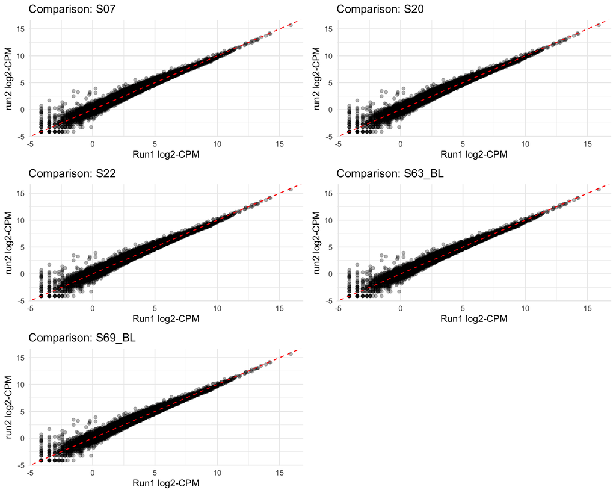

```r
# quartz(width = 10, height = 8, dpi = 110)
cowplot::plot_grid(plotlist = air_plots_run2, ncol = 2)
```

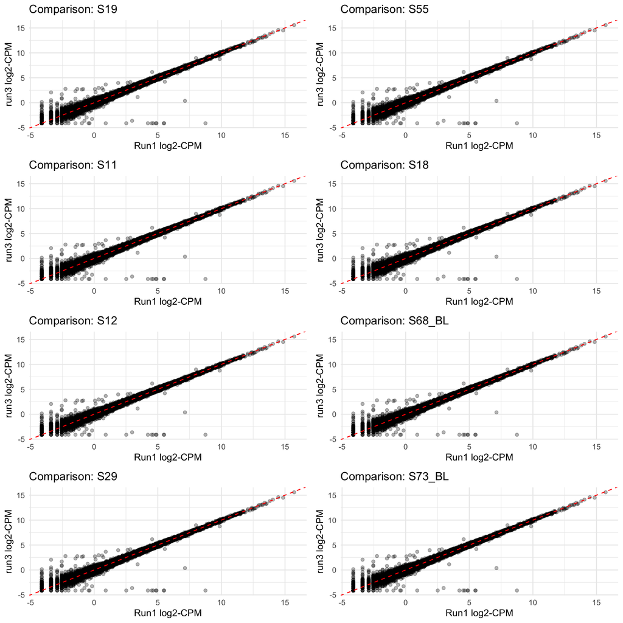

Figure: Comparison of technical replicates across sequencing runs. Scatterplots show log₂-transformed CPM values for the same biological samples sequenced in two independent sequencing runs. Each point represents one gene. The dashed red line indicates the 1:1 relationship expected for perfect agreement between runs. Overall, the replicate samples display high concordance, confirming that technical variation between sequencing runs is minimal relative to biological signal. Pearson and Spearman correlation coefficients were calculated for each sample pair and are summarized in the accompanying table.

```r
# quartz(width = 10, height = 11, dpi = 110)
cowplot::plot_grid(plotlist = air_plots_run3, ncol = 2)
```

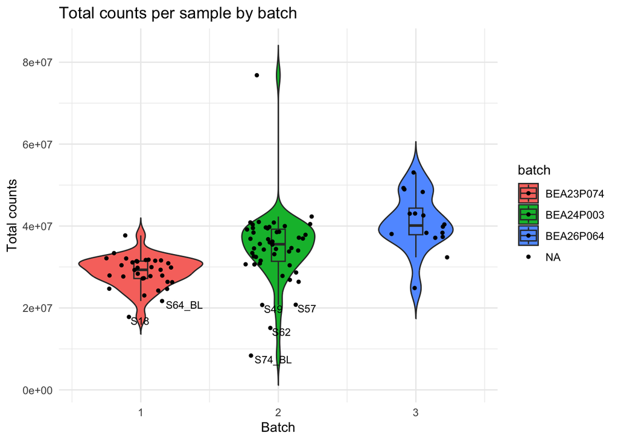

```r
ensembl_vars <- c("ensembl",
    "gene_biotype",
    "entrez",
    "Chr", "Start", "End", "Strand", "Length"
  )
# Convert counts to long format
long_counts <- countTable_filt %>%
  select(-any_of(ensembl_vars)) %>%
  pivot_longer(
    cols = -symbol,
    names_to = "svamp_ID",
    values_to = "counts"
  ) %>%
  mutate(is_mito = grepl("^MT", symbol)) %>%
  left_join(meta %>% select(svamp_ID, batch), by = "svamp_ID")


qc_df <- long_counts %>%
  group_by(svamp_ID, batch) %>%
  summarise(
    total_counts = sum(counts),
    mito_counts = sum(counts[is_mito]),
    percent_mito = mito_counts / total_counts * 100,
    .groups = "drop"
  )


add_jitter <- function(df, group, width = 0.25) {
  set.seed(123)
  df %>%
    mutate(
      group_num = as.numeric(factor({{ group }})),
      group_jit = group_num + runif(n(), -width, width)
    )
}
qc_df %>%
  add_jitter(., batch) %>%
  ggplot(., aes(x = group_jit, y = total_counts, fill = batch)) +
  geom_violin(aes(x = group_num), trim = FALSE) +
  geom_boxplot(aes(x = group_num), width = 0.1, outlier.shape = NA) +
  geom_point(size = 1) +
  geom_text(
    data = . %>% filter(total_counts < 2.3e7),
    aes(label = svamp_ID),
    vjust = 1,
    hjust = -0.1,
    size = 3
  ) +
  theme_minimal() +
  labs(
    title = "Total counts per sample by batch",
    x = "Batch",
    y = "Total counts"
  )
```

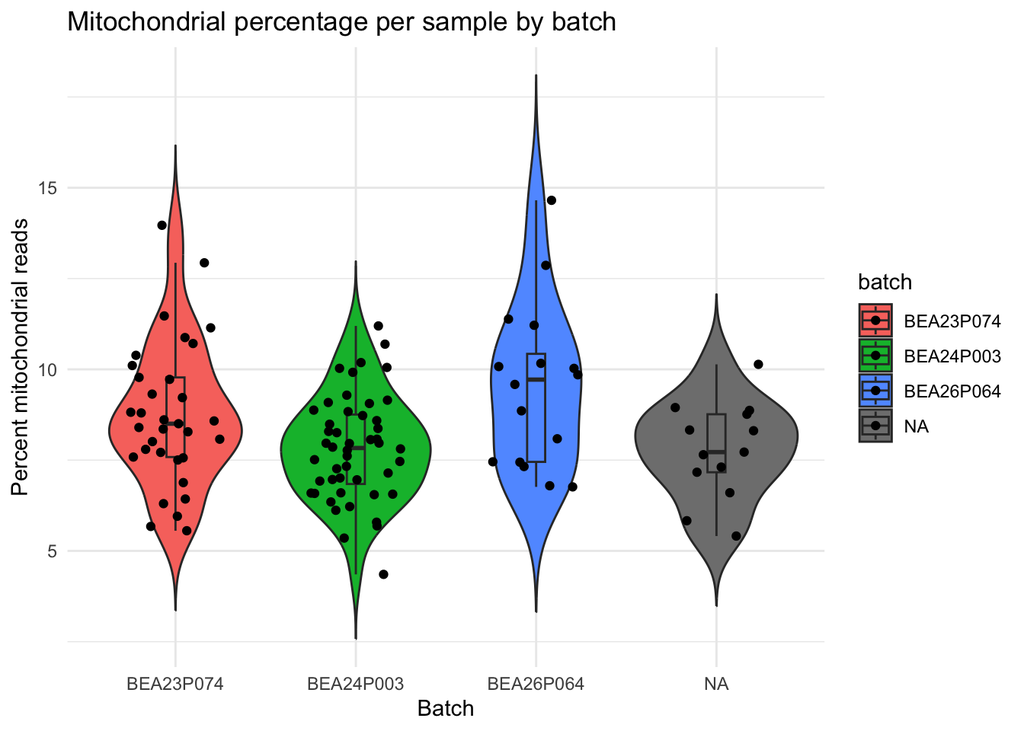

```r
ggplot(qc_df, aes(x = batch, y = percent_mito, fill = batch)) +
  geom_violin(trim = FALSE) +
  geom_boxplot(width = 0.1, outlier.shape = NA) +
  geom_jitter(width = 0.25) +
  theme_minimal() +
  labs(
    title = "Mitochondrial percentage per sample by batch",
    x = "Batch",
    y = "Percent mitochondrial reads"
  )
```

### Remove ctrl and second run samples

```r
countTable_final <- countTable_filt %>%
  # remove samples sequenced twice
  select(-ends_with("_run2"), -ends_with("_run3")) %>%
  # remove controll samples
  select(-starts_with("NA"))
```

```r
make_qc_plots <- function(countTable_filt, run = "run2") {
# Select symbol + the relevant columns
  n <- names(select(countTable, contains(paste0("_", run))))
  batch_smpl <- countTable_filt[, c("symbol", str_remove(n, "_run\\d"),n), drop = TRUE]

  # Convert to long format
  long_counts <- batch_smpl %>%
    pivot_longer(
      cols = -symbol,
      names_to = "sample",
      values_to = "counts"
    ) %>%
    mutate(
      run = ifelse(
        grepl("run", sample), run, "run1"),
      bio_sample = str_replace(sample, paste0("_", run, "$"), ""),
      is_mito = grepl("^MT", symbol)
    )

  # Calculate QC metrics
  qc_df <- long_counts %>%
    group_by(bio_sample, run) %>%
    summarise(
      total_counts = sum(counts),
      mito_counts = sum(counts[is_mito]),
      percent_mito = mito_counts / total_counts * 100,
      .groups = "drop"
    )

  # Total counts plot
  p_total <- ggplot(
    qc_df,
    aes(
      x = run,
      y = total_counts,
      group = bio_sample
    )
  ) +
    geom_line(alpha = 0.6) +
    geom_point(size = 3) +
    theme_minimal() +
    labs(
      title = paste0("Paired total counts: run1 vs ", run),
      x = "Sequencing run",
      y = "Total counts"
    )

  # Mitochondrial percentage plot
  p_mito <- ggplot(
    qc_df,
    aes(
      x = run,
      y = percent_mito,
      group = bio_sample
    )
  ) +
    geom_line(alpha = 0.6) +
    geom_point(size = 3) +
    theme_minimal() +
    labs(
      title = paste0("Paired mitochondrial percentage: run1 vs ", run),
      x = "Sequencing run",
      y = "Percent mitochondrial reads"
    )

  # Return both plots
  list(
    total_counts = p_total,
    percent_mito = p_mito,
    qc_df = qc_df
  )
}

qc_run2 <- make_qc_plots(
  countTable_filt = countTable_filt,
  run = "run2"
)

qc_run3 <- make_qc_plots(
  countTable_filt = countTable_filt,
  run = "run3"
)
```

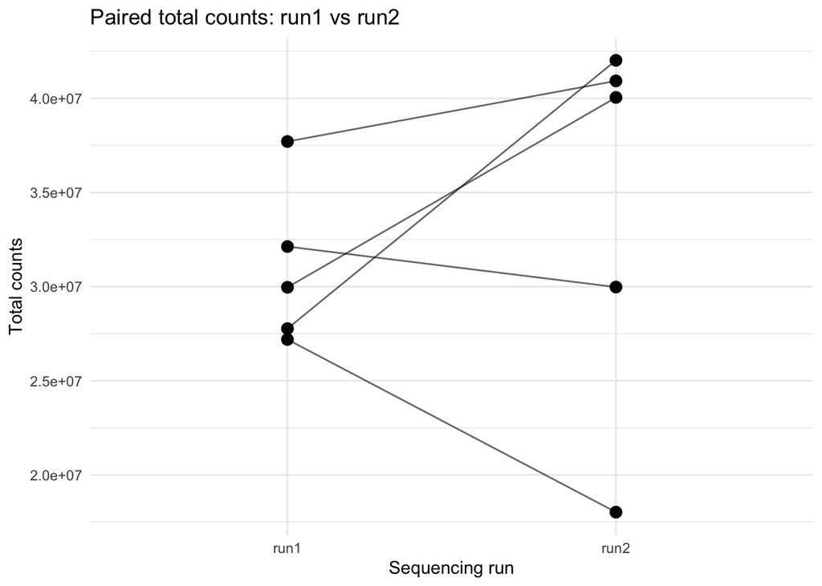

```r
qc_run2$total_counts
```

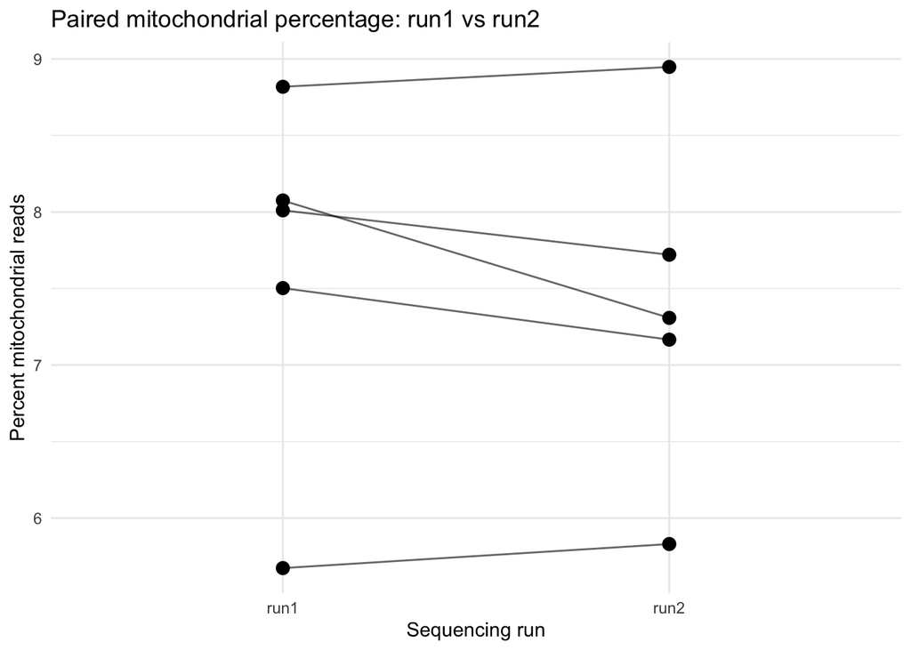

```r
qc_run2$percent_mito
```

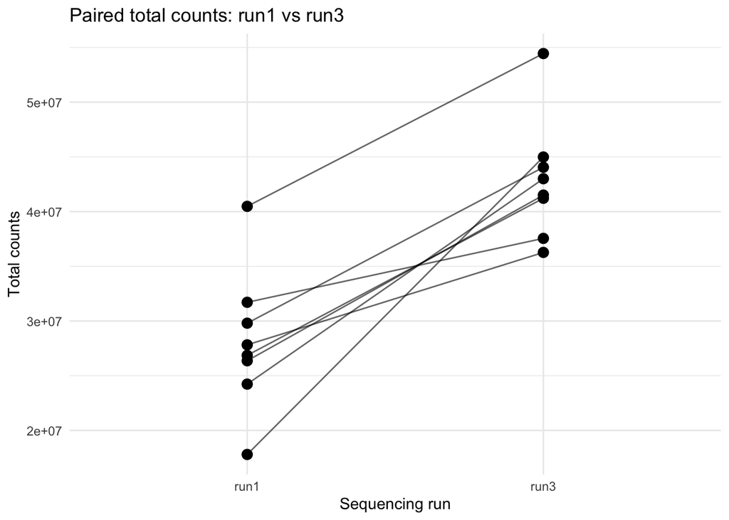

```r
qc_run3$total_counts
```

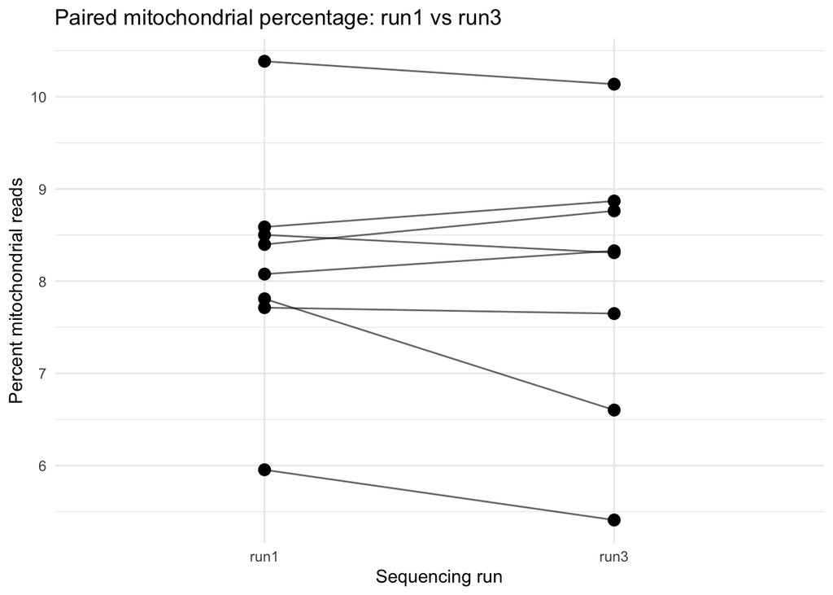

```r
qc_run3$percent_mito
```

## Step 6: Batch correction

```r
# Check consitency between group info and samples
intersect(MOFA_samples, meta$svamp_ID)
```

```
 [1] "S73_BL" "S25"    "S26"    "S27"    "S29"    "S30"    "S75_BL" "S77_BL"
 [9] "S78_BL" "S34"    "S35"    "S36"    "S37"    "S38"    "S39"    "S40"
[17] "S80_BL" "S41"    "S81_BL" "S42"    "S82_BL" "S43"    "S44"    "S45"
[25] "S46"    "S47"    "S48"    "S49"    "S83_BL" "S50"    "S51"    "S52"
[33] "S54"    "S55"    "S56"    "S57"    "S58"    "S59"    "S60"    "S61"
[41] "S62"    "S85_BL" "S74_BL" "S53"    "S86_BL" "S87_BL" "S88_BL" "S89_BL"
[49] "S90_BL" "S91_BL" "S07"    "S12"    "S01"    "S02"    "S03"    "S04"
[57] "S05"    "S06"    "S09"    "S10"    "S13"    "S15"    "S17"    "S19"
[65] "S20"    "S22"    "S23"    "S63_BL" "S64_BL" "S66_BL" "S67_BL" "S68_BL"
[73] "S69_BL" "S70_BL" "S71_BL" "S72_BL" "S08"    "S11"    "S18"
```

```r
setdiff(MOFA_samples, meta$svamp_ID)
```

```
character(0)
```

```r
gr <- c("0", "1-3", "4-5")

meta_ <- meta %>%
  filter(svamp_ID %in% MOFA_samples) %>%
  mutate(Clin_gr = factor(.$"Clin_gr", levels = gr)) %>%
  mutate(
    `Clinical score (0-5)` = factor(
      as.character(.$`Clinical score (0-5)`),
      levels = unique(.$`Clinical score (0-5)`)
    )
  )

design <- model.matrix(~Clin_gr, data = meta_)
rownames(design) <- meta_$svamp_ID
batch <- meta_$batch

# remove batch effect
expr_corrected <- removeBatchEffect(
  cpm_log_TMM[, rownames(design)],
  batch = batch,
  design = design
)
```

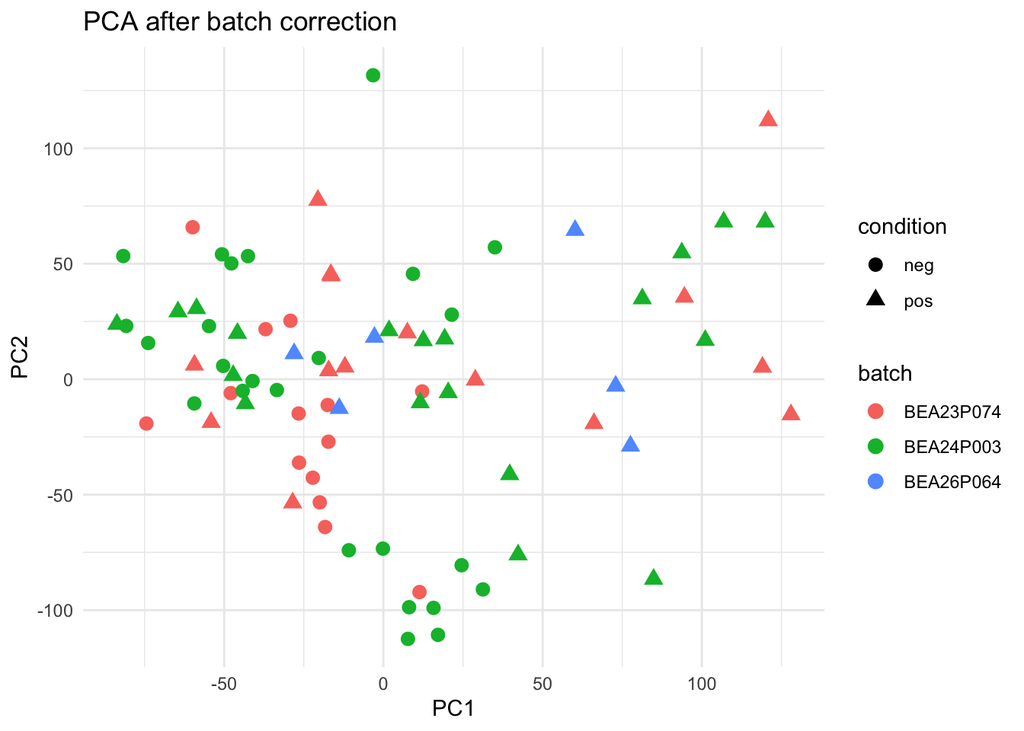

```r
plot_pca <- function(X, title) {
  pca <- prcomp(t(X), scale. = TRUE)

  pca_df <- data.frame(
    PC1 = pca$x[, 1],
    PC2 = pca$x[, 2],
    batch = meta_[["batch"]],
    condition = meta_[["pos"]]
  )

  ggplot(pca_df, aes(x = PC1, y = PC2, color = batch, shape = condition)) +
    geom_point(size = 3) +
    theme_minimal() +
    labs(title = paste0("PCA ", title, " batch correction"))
}

plot_pca(expr_corrected, "after")
```

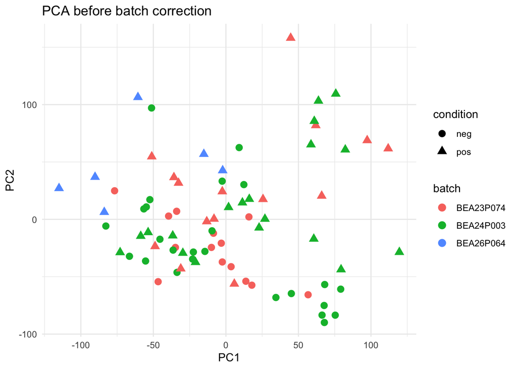

```r
plot_pca(cpm_log_TMM[, rownames(design)], "before")
```

### Save batch corrected and filtered and normalized expression values

```r
########################
# SAVE NORMALIZED DATA #
########################
expr_corrected %>%
  as_tibble(., rownames = "symbol") %>%
  right_join(ensembl_info, ., by = "symbol") %>%
  write_csv(., "../Results/MixOmic/Transcriptomics_batch_filt.csv")
# expr_corrected <- read_csv("../Results/MixOmic/Transcriptomics_batch_filt.csv") %>% data.frame(., row.names = 1)
```

## Step 7: UMAP and clustering

Unsupervised UMAP used for unsupervised clustering of transcriptomic samples. Not used right now, as I moved this code to the MOFA script

```r
#### UMAP analysis ####
v <- list(TRX = expr_corrected)
set.seed(1)
UMAP_df <- v %>%
  map(., ~ t(.x)) %>%
  # PCA
  map(., ~ prcomp(.x, scale = T, center = T)) %>%
  # KNN graph
  map(
    .,
    ~ RcppHNSW::hnsw_knn(as.matrix(.x$x[, 1:10]), k = 8, distance = "cosine")
  ) %>%
  {
    . ->> knn
  } %>%

  # UMAP
  map(
    .,
    ~ uwot::umap(
      X = NULL,
      nn_method = .x,
      n_components = 2,
      ret_extra = c("model", "fgraph"),
      verbose = T,
      min_dist = 0.1,
      spread = 0.3,
      approx_pow = TRUE,
      repulsion_strength = .2,
      negative_sample_rate = 30,
      n_epochs = 200,
      n_threads = 8
    )$embedding
  ) %>%
  imap(
    .,
    ~ tibble(
      "UMAP 1" = .x[, 1],
      "UMAP 2" = .x[, 2],
      "ID" = colnames(v[[.y]])
    )
  ) %>%
  map(., ~ left_join(., meta[, 1:15], by = c("ID" = "svamp_ID")))
```

```
13:11:20 Note: model requested with precomputed neighbors. For transforming new data, distance data must be provided separately
```

```r
# BUILD GRAPH
g2 <- igraph::graph_from_data_frame(
  data.frame(
    from = rep(
      seq_len(nrow(knn$TRX$idx)),
      ncol(knn$TRX$idx)
    ),
    to = c(knn$TRX$idx),
    weight = 1 - c(knn$TRX$dist)
  ),
  directed = FALSE
)

# IDENTIFY SAMPLE CLUSTERS
set.seed(42)
resolutions <- c(
  `4` = 0.6,
  `5` = 0.8,
  `6` = 0.9,
  `7` = 1.1,
  `8` = 1.2
)

for (i in names(resolutions)) {
  cl <- igraph::cluster_louvain(
    g2,
    resolution = resolutions[[i]],
    weights = igraph::E(g2)$weight
  )

  UMAP_df$TRX[[paste0("trx_louvain_", i)]] <- factor(cl$membership)
}
```

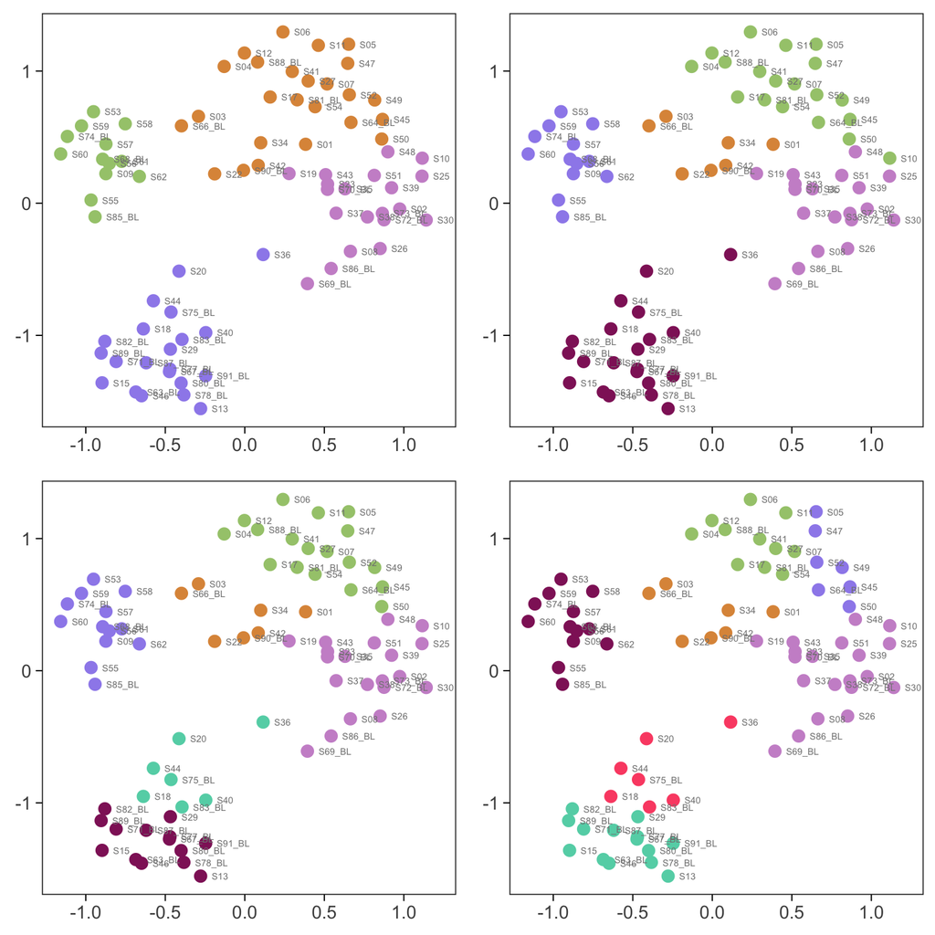

```r
UMAP_fun <- function(
  umap_df,
  group_var,
  txt_var = NULL,
  shape_gr = NULL,
  shape = NULL
) {
  p <- ggplot(
    umap_df,
    aes(
      x = `UMAP 1`,
      y = `UMAP 2`,
      fill = .data[[group_var]],
      color = .data[[group_var]],
      #shape = .data[[shape_gr]]
    )
  ) +
    #geom_jitter( shape=21, size=3, color="white", width=.5, height=.5) +  # Tassos used jitter
    geom_point(
      size = 3,
      alpha = 1,
      aes(shape = if (!is.null(shape_gr)) .data[[shape_gr]] else NULL)
    ) +
    scale_colour_manual(
      values = pal[["trx_louvain"]],
      name = "",
      aesthetics = c("colour", "fill")
    ) +
    {
      if (!is.null(shape_gr) && !is.null(shape)) {
        scale_shape_manual(values = shape, name = "")
      }
    } +
    # scale_shape_manual(values = c(21, 5, 4), name = "" ) + #specify individual shapes+
    {
      if (!is.null(txt_var)) {
        geom_text(
          data = umap_df,
          aes(x = `UMAP 1`, y = `UMAP 2`, label = .data[[txt_var]]),
          size = 2,
          hjust = 0,
          nudge_x = 0.07,
          color = "gray51"
        )
      }
    } +
    theme_bw(base_size = 14) +
    theme(
      line = element_blank(),
      axis.ticks = element_line(color = "black"),
      aspect.ratio = 1,
      axis.title = element_blank()
    )
  return(p)
}
# quartz(width = 8, height = 8, dpi = 150)
pal <- c(pal,list(
  trx_louvain = c(
    "#de9548",
    "#cc93cf",
    "#a5c97b",
    "#9e8dec",
    "#902267",
    "#63d3b4",
    '#FB5273',
    "#984EA3",
    "#B3CDE3"
  ))
)
n_clus <- c("trx_louvain_4", "trx_louvain_5", "trx_louvain_6", "trx_louvain_7")
plots <- map(n_clus, ~UMAP_fun(UMAP_df$TRX, .x, txt_var = "ID")+ theme(legend.position = "none"))
plot_grid(plotlist = plots)
```

```r
select(
  UMAP_df$TRX,
  svamp_ID = "ID",
  `UMAP 1`,
  `UMAP 2`,
  paste0("trx_louvain_", 4:7)
) %>%
  write_csv(., "../Results/Trx_louvain_gr.csv")
```

## Step 7: Differential Gene Expression analysis

```r
##################
# DEG's FUNCTION #
##################
# df <- meta_trx
# sample_df <- meta
# group <- "Clin_gr"

edgR_dge.fun <- function(CountMatrix, gr, sample_df, confound = NULL) {
  #groups <- sample_df[, group]
  groups <- pull(sample_df, gr)
  n_gr <- length(na.omit(unique(groups)))

  if (any(is.na(groups))) {
    groups <- tidyr::replace_na(groups, "X")
  }

  if (!is.null(confound)) {
    c <- "_conf"
    design <- design
  } else {
    c <- "_no_conf"
    design <- model.matrix(~groups, data = sample_df) # without confounders
  }

  colnames(design) <- sub(gr, "", colnames(design))
  colnames(design) <- sub("\\(Intercept\\)", "Intercept", colnames(design))
  colnames(design) <- sub(" ", "_", colnames(design))

  y <- DGEList(counts = CountMatrix, remove.zeros = T)
  y <- calcNormFactors(y, method = "TMM")
  y <- estimateGLMCommonDisp(y, design)
  y <- estimateGLMTagwiseDisp(y, design)
  fit <- glmFit(y, design)

  lrt <- glmLRT(fit, coef = 2:n_gr) # with intercept
  top <- topTags(lrt, adjust.method = "BH", n = "all", sort.by = "p.value")[[1]]
  colnames(top) <- sub(gr, "", colnames(top))
  top <- cbind(LogFC.intercept = 0, top) # with intercept
  top <- rownames_to_column(top, var = "Genes")

  return(list(design = design, y = y, fit = fit, lrt = lrt, top = top, c = c))
}
```

```r
##################
# DEG's FUNCTION #
##################
# sample_df <- meta_filt
# gr <- "RVVC_pos"

edgR_dge.fun <- function(CountMatrix, gr, sample_df, confound = NULL) {
  #groups <- sample_df[, group]
  groups <- pull(sample_df, gr)
  n_gr <- length(na.omit(unique(groups)))

  if (any(is.na(groups))) {
    groups <- tidyr::replace_na(groups, "X")
  }

  if (!is.null(confound)) {
    c <- "_conf"
    design <- design
  } else {
    c <- "_no_conf"
    design <- model.matrix(~groups, data = sample_df) # without confounders
  }

  colnames(design) <- sub("groups", "", colnames(design))
  colnames(design) <- sub("\\(Intercept\\)", "Intercept", colnames(design))
  #colnames(design) <- sub(" ", "_", colnames(design))

  y <- DGEList(counts = CountMatrix, remove.zeros = T)
  y <- calcNormFactors(y, method = "TMM")
  y <- estimateGLMCommonDisp(y, design)
  y <- estimateGLMTagwiseDisp(y, design)
  fit <- glmFit(y, design)

  lrt <- glmLRT(fit, coef = 2:n_gr) # with intercept
  top <- topTags(lrt, adjust.method = "BH", n = "all", sort.by = "p.value")[[1]]
  colnames(top) <- sub("groups", "", colnames(top))
  top <- cbind(LogFC.intercept = 0, top) # with intercept
  top <- rownames_to_column(top, var = "Genes")

  return(list(design = design, y = y, fit = fit, lrt = lrt, top = top, c = c))
}
```

```r
# nesscary only if you want to add confounders
# design <- model.matrix(~ Clin_gr + `Age (years)`, data = meta)
dge <- countTable_final %>%
  select(symbol, any_of(meta_$svamp_ID)) %>%
  column_to_rownames(., var = "symbol") %>%
  edgR_dge.fun(., "RVVC_pos", meta_, confound = NULL)
```

```
calcNormFactors has been renamed to normLibSizes
```

```r
# get DEGs for RVVCpos groups

fc_cols <- sort(grep("logFC", colnames(dge$top), value = TRUE))

DEG_list <- map(
  set_names(fc_cols),
  ~ {
    fc_col <- .x # current column being processed

    dge$top %>%
      as_tibble() %>%
      mutate(
        Regulation = case_when(
          !!sym(fc_col) > 0 & FDR < 0.05 ~ "UP",
          !!sym(fc_col) < 0 & FDR < 0.05 ~ "DOWN",
          TRUE ~ "NOT SIG."
        )
      ) %>%
      filter(Regulation %in% c("UP", "DOWN")) %>%
      dplyr::select(
        Genes,
        {{ fc_col }},
        logCPM,
        LR,
        PValue,
        FDR,
        Regulation
      ) %>%
      group_by(Regulation) %>%
      # slice_max(order_by = abs(!!sym(fc_col)), n = 10) %>%
      ungroup() %>%
      arrange(!!sym(fc_col))
  }
)

D <- DEG_list %>%
  imap(., ~ group_by(.x, Regulation)) %>%
  imap(., ~ slice_max(.x, order_by = abs(!!sym(.y)), n = 10)) %>%
  imap(., ~ arrange(.x, !!sym(.y)))

names(D)
```

```
[1] "logFC.Control_pos" "logFC.RVVC_neg"    "logFC.RVVC_pos"
```

```r
D[[3]] %>%
  knitr::kable(., digits = 1)
```

| Genes | logFC.RVVC_pos | logCPM | LR | PValue | FDR | Regulation |
| --- | --- | --- | --- | --- | --- | --- |
| CDSN | -3.6 | 4.7 | 31.7 | 0 | 0 | DOWN |
| LCE1F | -2.9 | -2.1 | 20.9 | 0 | 0 | DOWN |
| DEFB103B | -2.9 | -2.3 | 13.8 | 0 | 0 | DOWN |
| DEFB103A | -2.8 | -1.6 | 11.8 | 0 | 0 | DOWN |
| KRT36 | -2.5 | 1.0 | 30.9 | 0 | 0 | DOWN |
| C5orf46 | -2.5 | 0.7 | 24.9 | 0 | 0 | DOWN |
| SERPINA12 | -2.4 | 1.7 | 28.1 | 0 | 0 | DOWN |
| THRSP | -2.4 | -2.3 | 42.4 | 0 | 0 | DOWN |
| SLC14A1 | -2.1 | 0.3 | 24.0 | 0 | 0 | DOWN |
| AADAC | -2.1 | -0.2 | 31.9 | 0 | 0 | DOWN |
| MMP7 | 5.7 | 1.9 | 44.5 | 0 | 0 | UP |
| OSM | 5.8 | 0.8 | 97.5 | 0 | 0 | UP |
| CSF3 | 6.3 | 1.3 | 81.6 | 0 | 0 | UP |
| NOS2 | 6.6 | 4.6 | 77.8 | 0 | 0 | UP |
| IL22 | 6.7 | -0.4 | 68.6 | 0 | 0 | UP |
| CXCL6 | 7.1 | 3.0 | 81.3 | 0 | 0 | UP |
| LTF | 7.3 | 5.0 | 129.4 | 0 | 0 | UP |
| IL19 | 7.6 | 3.8 | 67.7 | 0 | 0 | UP |
| CXCL8 | 8.3 | 4.0 | 95.6 | 0 | 0 | UP |
| CXCL1 | 9.0 | 5.7 | 108.7 | 0 | 0 | UP |